# Part 4: Masking and filtering of spectra

Patrick Schratz

Sat 06 Jul 2019

**Note**

This part uses the built-in dataset `spectral_data` from the `hsdar` package. The reason is that this dataset has more “errors” showing the effect of filtering and masking compared to the hyperspectral image from the previous parts.

# Accounting for errors in spectra

Before applying a continuum removal correction on a spectrum, it is important to check if the spectra signature contains errors and to account them.

```r
data("spectral_data")
spectral_data
```

```
Summary of Speclib


History of usage
---------------------
(1)   Reflectance = mean applied to matrix spectra by attribute 'site'


Summary of spectra
---------------------
Total number of spectra : 45
Number of bands : 1401
Width of bands : 1
Spectral range of data : 305 - 1705 nm


Speclib contains SI
---------------------
    Variables Classes
1        year integer
2      season  factor
3        site  factor
4 chlorophyll numeric
```

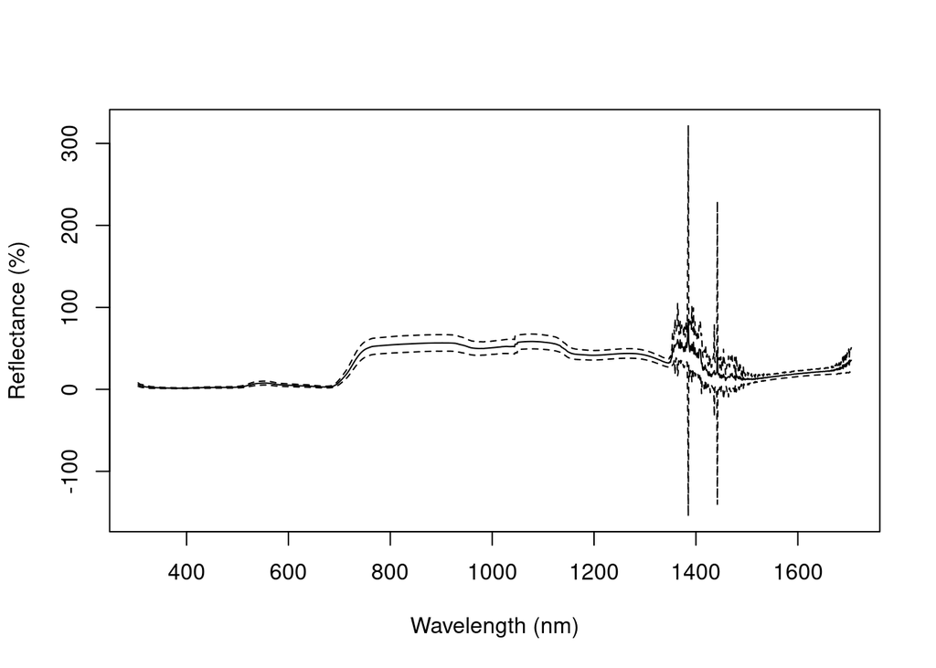

```r
plot(spectral_data)
```

Some artifacts appear between 1050 nm and 1400 nm.  
To account for these, we can mask out the problematic wavelength ranges.

```r
spectral_data_masked = spectral_data
mask(spectral_data_masked) <- c(1040, 1060, 1300, 1450)
spectral_data_masked
```

```
Summary of Speclib


History of usage
---------------------
(1)   Reflectance = mean applied to matrix spectra by attribute 'site'
(2)   Apply mask to spectra


Summary of spectra
---------------------
Total number of spectra : 45
Number of bands : 1233
Width of bands : 1
Spectral range of data : 305 - 1705 nm


Speclib contains SI
---------------------
    Variables Classes
1        year integer
2      season  factor
3        site  factor
4 chlorophyll numeric
```

Note that in the summary if the spectra this change has been logged (in (2)) and the number of bands was reduced from 1401 to 1233.

Let’s plot both the full spectrum and the masked one side by side:

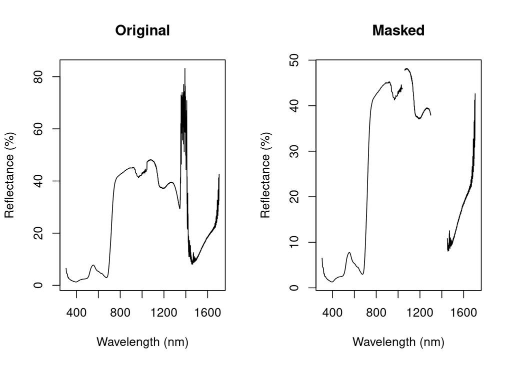

```r
par(mfrow = c(1, 2))

plot(spectral_data, FUN = 1, main = "Original")

plot(spectral_data_masked, FUN = 1, main = "Masked")
```

# Interpolation of missing/wrong values

After masking, the masked areas can be filled again using `hsdar::interpolate.mask()`.

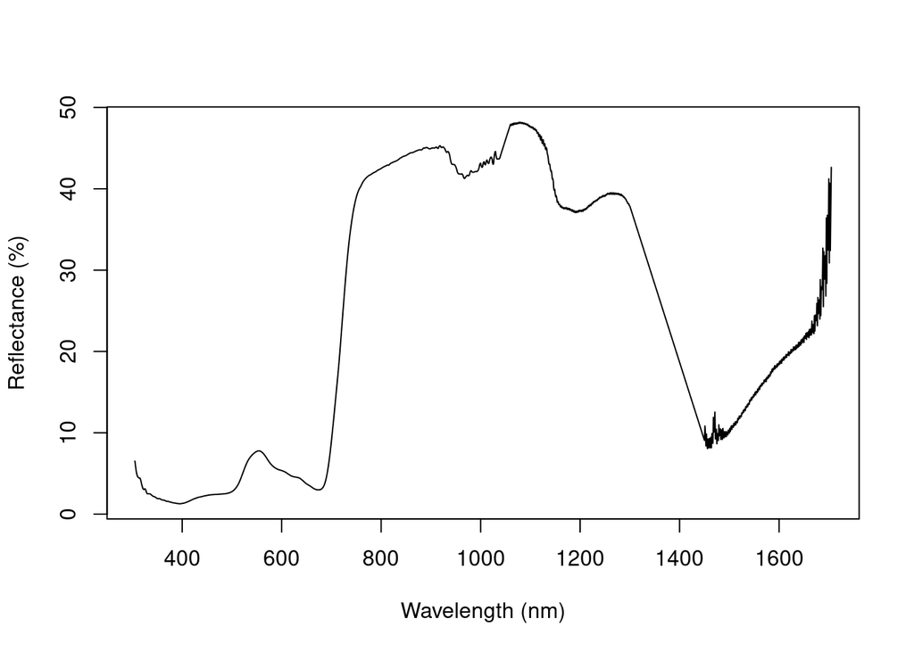

```r
spectral_data_masked_interpolated <- interpolate.mask(spectral_data_masked)

plot(spectral_data_masked_interpolated, FUN = 1)
```

# Filtering (smoothing) of spectra

Taking a closer look at the spectrum, there is a possible need to smooth it in the range between 1000 nm and 1150 nm.

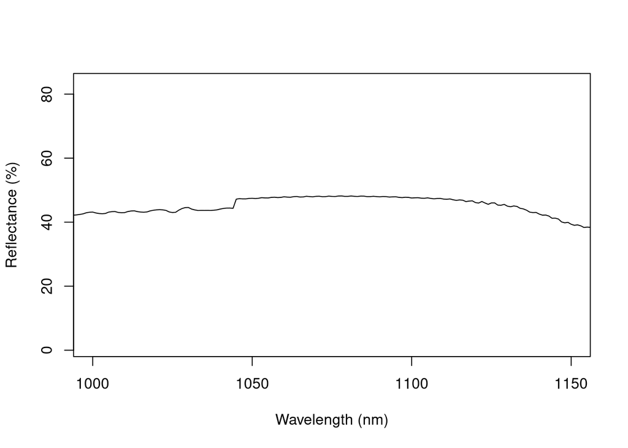

```r
plot(spectral_data, FUN = 1, xlim = c(1000, 1150))
```

The `hsdar` package comes with several “filter” methods to smooth spectra:

- ‘Savitzky-Golay’
- ‘Spline’
- ‘Locally Weighted Scatterplot Smoothing (Lowess)’
- ‘Mean Filter’

The function `hsdar::smoothSpeclib()` works on objects of class `Speclib`.  
Arguments vary depending on the chosen method. See `?smoothSpeclib()` for more information.

```r
sgolay <- smoothSpeclib(spectral_data, method = "sgolay", n = 25)

lowess <- smoothSpeclib(spectral_data, method = "lowess", f = .01)

meanflt <- smoothSpeclib(spectral_data, method = "mean", p = 5)

spline <- smoothSpeclib(spectral_data, method = "spline",
                        n = round(nbands(spectral_data) / 10, 0))
```

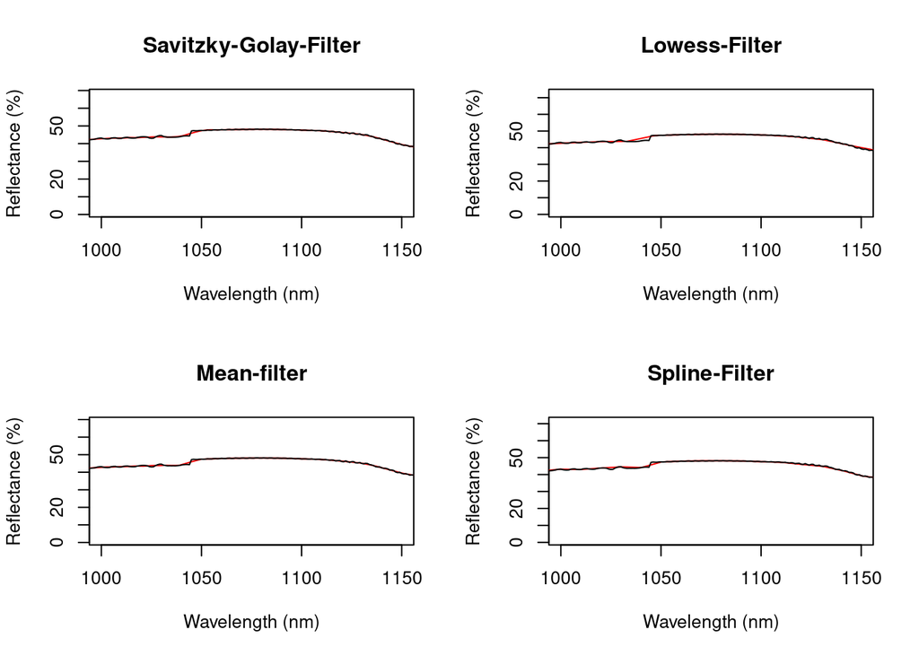

```r
par(mfrow = c(2, 2))

plot(sgolay, FUN = 1, xlim = c(1000, 1150), col = "red", main = "Savitzky-Golay-Filter")
plot(spectral_data, FUN = 1, new = FALSE) #raw spectrum

plot(lowess, FUN = 1, xlim = c(1000, 1150), col = "red", main = "Lowess-Filter")
plot(spectral_data, FUN = 1, new = FALSE) #raw spectrum

plot(meanflt, FUN = 1, xlim = c(1000, 1150), col = "red", main = "Mean-filter")
plot(spectral_data, FUN = 1, new = FALSE) #raw spectrum

plot(spline, FUN = 1, xlim = c(1000, 1150), col = "red", main = "Spline-Filter")
plot(spectral_data, FUN = 1, new = FALSE) #raw spectrum
```

You see the different behavior of the smoothing methods. Click on the Figure to zoom in ;-)

It is important to know the implications of applying the respective filters on a spectrum. The idea behind the filtering of spectra is to avoid small local maxima which are not associated with reflection maxima.  
When filtering spectra there is a risk of loosing important information because small local maxima which are not associated with reflection characteristics might get smoothed out.

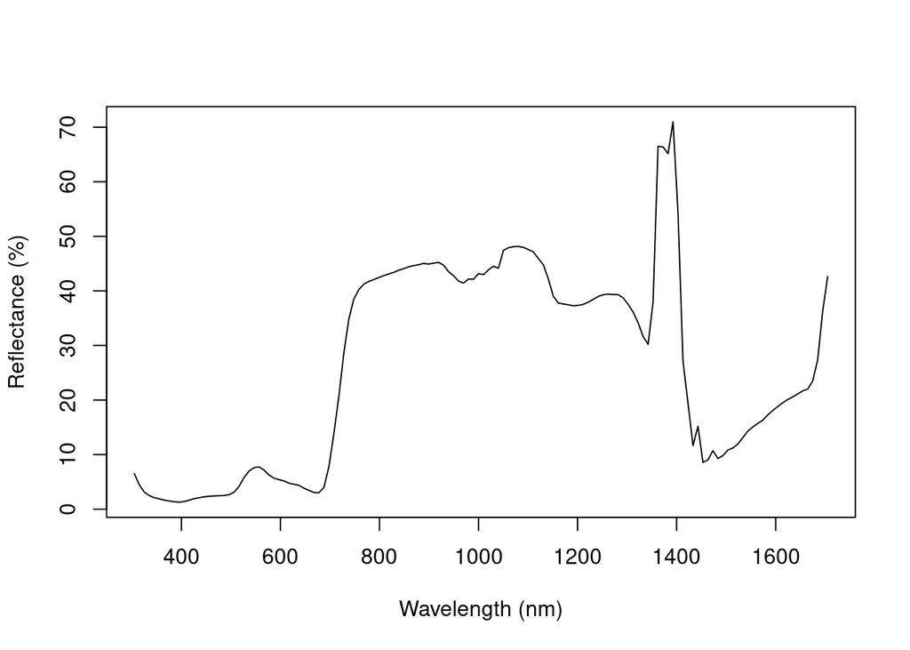

```r
par(mfrow = c(1, 1))
plot(spline, FUN = 1)
```

(The example shown here is just for demonstration purposes and the applied filter range here does not claim to make sense in practice.)